# LIDAR plot

Roger Downing

7 October 2015

# Investigation of sample LIDAR data

Sample data is provided as a 775 megabyte zip file, which contains:

1. Directory of generated wake field images
2. Video composed of wake field images in series
3. LIDAR hardware installation documentation
4. Text file of LIDAR operating temperatures and input values, recorded every 2.5 minutes
5. 24 directories, ‘00’ to ‘23’, each holding 95 ‘.scn’ files

The 24 directories each represent one hour of the day of August 23rd, 2014. Each ‘.scn’ file is a single LIDAR scan from that hour and lasting roughly 30 seconds.

```
## Filename:\tC:\Lidar\Data\2014\201408\20140823\00\2138233_23081400_25.scn\t
## Campaign code:\taltenbruch2 nacelle t1 a2 dg 0406 1357\t\t\t\t\t\t
## Campaign number:\t304\t\t\t\t\t\t
## Rays in scan:\t21\t\t\t\t\t\t
## Start time: \t00:01:03\t\t\t\t\t\t
## Range gate\tDoppler\tIntensity\tRay time\tAz\tEl\tPitch\tRoll
## 0\t38.618607\t0.919469\t00:01:03\t150\t0\t1.538\t-0.525
## 1\t-39.102631\t0.967835\t00:01:03\t150\t0\t1.538\t-0.525
## 2\t3.780688\t1.016727\t00:01:03\t150\t0\t1.538\t-0.525
## 3\t2.595855\t1.020028\t00:01:03\t150\t0\t1.538\t-0.525
```

The file appears to be a tab-separated variable file with headers and 5 lines of preamble.

```r
# Read in a file of LIDAR data as a CSV file with tab separators, skipping the first 5 lines and using column headers
lidar <- read.csv( lidar.filename, skip=5, header=TRUE, sep="\t" )

summary( lidar )
```

```
##    Range.gate       Doppler          Intensity          Ray.time
##  Min.   : 0.00   Min.   :-39.599   Min.   :0.8876   00:01:03: 16
##  1st Qu.: 3.75   1st Qu.:  3.685   1st Qu.:1.0359   00:01:05: 16
##  Median : 7.50   Median :  4.908   Median :1.0606   00:01:06: 16
##  Mean   : 7.50   Mean   :  6.885   Mean   :1.0544   00:01:08: 16
##  3rd Qu.:11.25   3rd Qu.:  6.767   3rd Qu.:1.0844   00:01:09: 16
##  Max.   :15.00   Max.   : 38.619   Max.   :1.1209   00:01:10: 16
##                                                     (Other) :240
##        Az            El        Pitch              Roll
##  Min.   :150   Min.   :0   Min.   :-0.7060   Min.   :-3.9930
##  1st Qu.:174   1st Qu.:0   1st Qu.: 0.0080   1st Qu.:-1.0350
##  Median :180   Median :0   Median : 0.4160   Median :-0.3210
##  Mean   :180   Mean   :0   Mean   : 0.5083   Mean   :-0.4327
##  3rd Qu.:186   3rd Qu.:0   3rd Qu.: 1.2320   3rd Qu.: 0.6990
##  Max.   :210   Max.   :0   Max.   : 1.6400   Max.   : 3.4540
##
```

The range of Doppler values appears unusual:

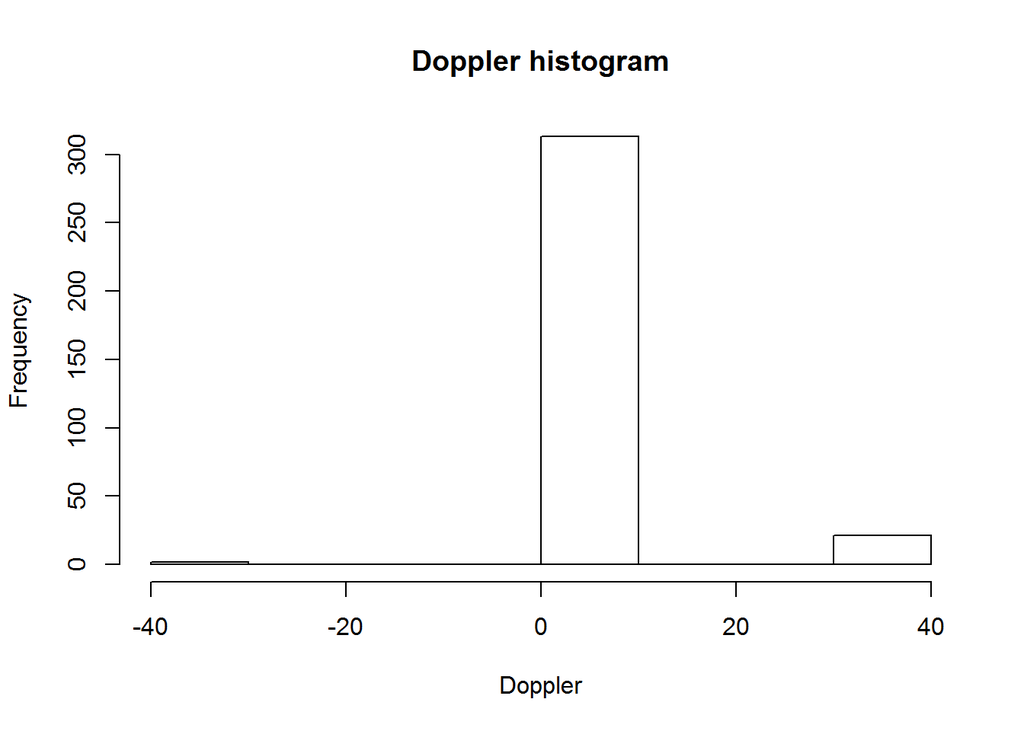

Looks like there are spurious outliers which should be ignored. The ‘Range.gate’ values do not appear to be actual ranges, but rather refer to a portion of a range. A web search determines that the range gate for a Galion 4000 LIDAR system is 30 metres. Looking at the included imagery of wake fields, it seems that although the range gates start at zero, the first measurement range is from 45 metres, so:

```r
# Calculate actual ranges by multiplying the range gate by 30 (metres) and then adding 15 for the midpoint
lidar$Range = ( lidar$Range.gate + 1 ) * 30 + 15
```

Provided azimuth is in degrees, but the R trig functions use radians:

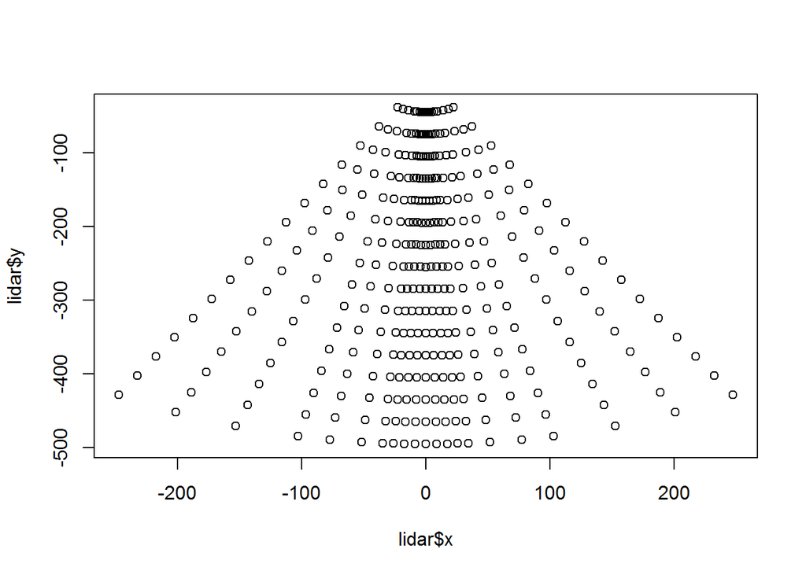

```r
# Convert azimuth angle to radians
lidar$Az = lidar$Az * pi / 180

# Change polar to cartesian coordinates
lidar$x = lidar$Range * sin( lidar$Az )
lidar$y = lidar$Range * cos( lidar$Az )

# Plot our point distribution for sanity-checking
plot( lidar$x, lidar$y )
```

Now that we have the data plotting onto a grid, we can perform bilinear 2d interpolation of the values. Bilinear was chosen as a simple but effective way of interpolating on a plane, but it may not necessarily be the right choice. Someone more versed in fluid dynamics could advise.

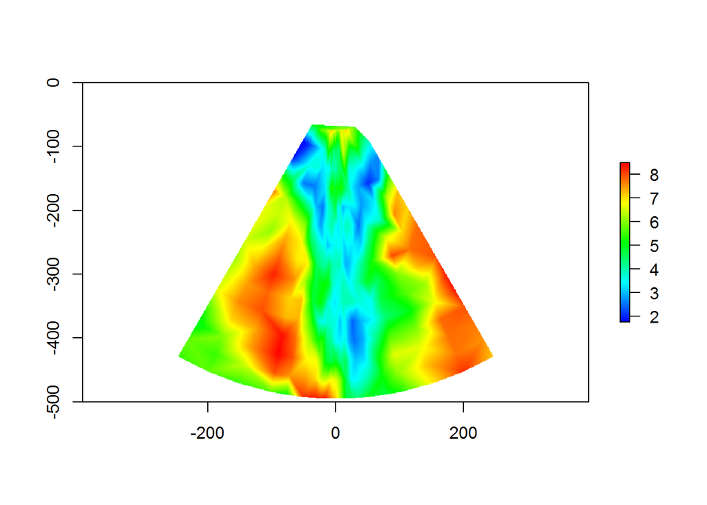

A side-by-side comparison of this image with the corresponding provided image shows great similarity but significant difference. An investigation into suitable interpolation is required to make sure that the chosen method is appropriate.

## Horizontal wind speed plotting

Measurement of the wake wind speed deficit is a useful parameter:

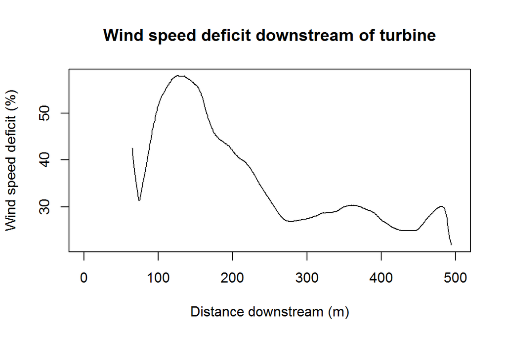

## Wake Identification

Can we determine the region of the image over which the wake stretches? We should find the centre-line, and then calculate the full width half-maximum as a way of estimating the lateral extent of the wake. Plot an example cross-section:

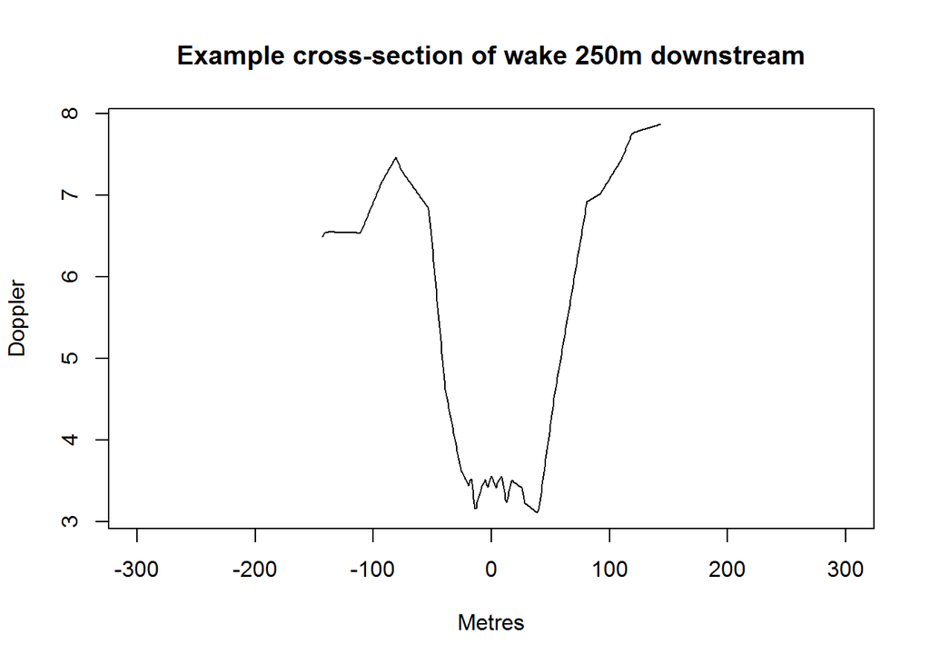

Smooth the data before we try to extract the minimum value:

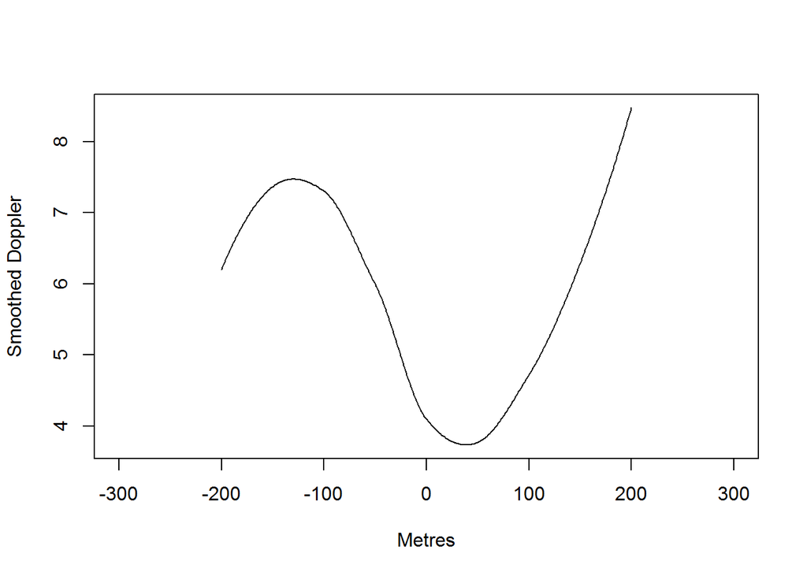

Now, redraw the image with the centre-line added:

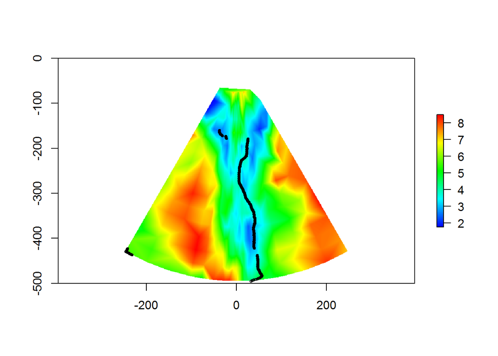

The tail end of the wake could be used as a coarse estimation of incident wind direction:

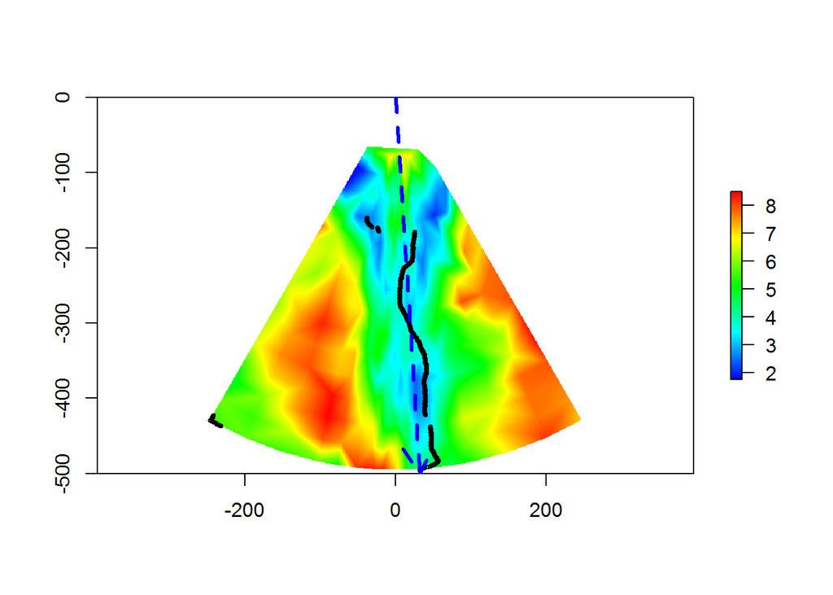

The angle of incidence can then be estimated at 3.66 degrees counter-clockwise to the turbine heading.